# Perceptron

Is one of the earliest and most fundamental algorithms in the field of machine learning that has laid the foundation for many more complex and sophisticated algorithms that have been developed over the years.

The perceptron is based on the concept of a single neuron in the human brain, A single neuron in the human brain is just receiving some inputs and if the inputs are high, it activates and send the signal to the next neuron.

# How does it work?

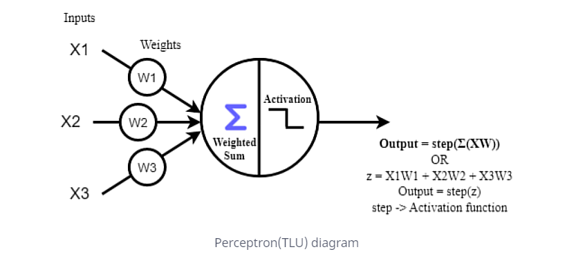

The Perceptron contains some input (X1, X2, and, X3). Each input has its own corresponding weights (W1, W2, and W3). These weights are basically the main point of Perceptrons, which determine the strength of each input signal to it.

It computes the weighted sum of the inputs (z = X1W1 + X2W2 + X3W3 ...... + XnWn) and then these weighted sums of inputs are passed through an activation function also known as the step function.

# Inputs or features

Requires a set of input values, often referred to as features. These features can represent any kind of data, such as pixel values in an image, numerical values in a dataset, or any other measurable quantities.

# Weights

Each input is associated with a weight. These weights determine the significance or importance of each input. The Perceptron learns to adjust these weights during training to make accurate predictions.

# z = (XW + bias)

is an additional input (often set to 1) that has its own associated weight. The bias helps control the output when all the other inputs are zero. It allows the Perceptron to have some flexibility in its predictions.

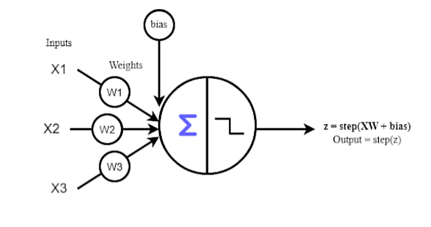

# Weighted sum

The Perceptron computes the weighted sum of the inputs by multiplying each input by its weight and summing them up.

## Activation functions

Are mathematical functions that can be used in Perceptrons to determine the output given its input.

Some common types of activation functions used in Perceptrons are the Sign function, Heaviside function, Sigmoid function, ReLU function, etc.

For this example a step function is used The output is a certain value, A1, if the input sum is above a certain threshold and A0 if the input sum is below a certain threshold. The values used by the Perceptron were A1 = 1 and A0 = 0.

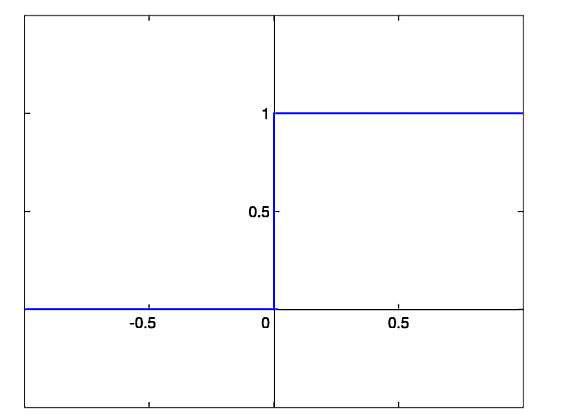

# Prediction or Output

The output of the activation function is the final prediction or output of the Perceptron. It represents the Perceptron's decision on whether the given input belongs to one class (1) or another class (0)

# Learning

the Perceptron can be trained by finding the error made by the algorithm and finding the weights that reduce this error as much as possible.

The algorithm will first make a prediction based on the training data given, then this prediction is compared with the actual desired output. The error is calculated for each of the training instances by comparing the prediction and actual output, finally, this error is reduced during the training process and the weights corresponding to the correct predictions are adjusted accordingly.

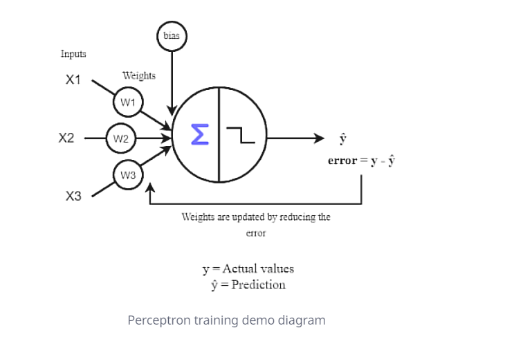

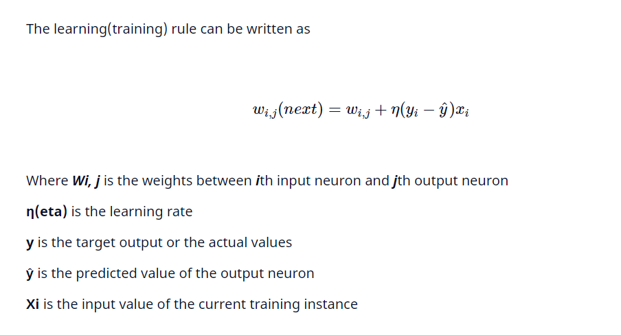

The algorithm is being trained by updating the weights until getting the optimal results. The learning rate(η) is required to determine the length of each step taken for finding optimal weights.

## Loss function

Is a method of evaluating how well your machine learning algorithm models your featured data set.

The loss function is directly related to the predictions of the model you’ve built. If your loss function value is low, your model will provide good results.

### For this example we use MEAN SQUARE ERROR / QUADRATIC LOSS

We define MSE loss function as the average of squared differences between the actual and the predicted value.

The MSE loss function penalizes the model for making large errors by squaring them and this property makes the MSE cost function less robust to outliers. For that reason it is not recomended for datasetw with many outliers

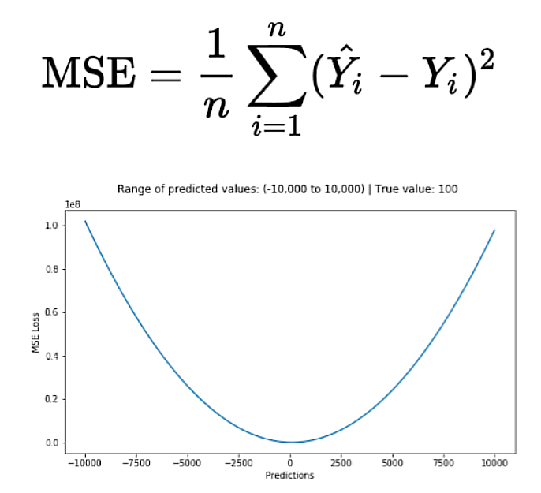

# Optimization

Optimization is the process where we train the model iteratively that results in a maximum and minimum function evaluation.

For this example we will use Gradient descent. It is an optimization algorithm and it finds out the local minima of a differentiable function.

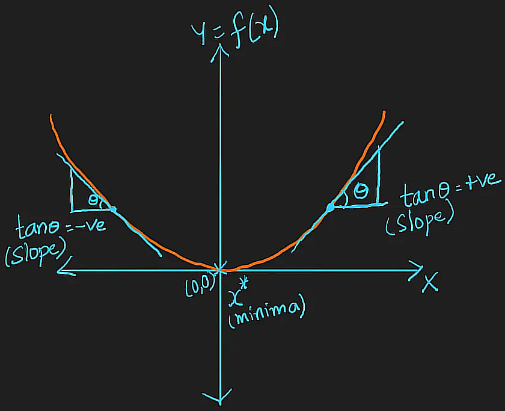

### How does the Gradient Descent Algorithm work?

Calculate X*- local minimum of the function Y=X².

- Pick an initial point X₀ at random
- Calculate X₁ = X₀-r[df/dx] at X₀. r is Learning Rate (we’ll discuss r in Learning Rate Section). Let us take r=1. Here, df/dx is nothing but the gradient.
- Calculate X₂ = X₁-r[df/dx] at X₁.
- Calculate for all the points: X₁, X₂, X₃, ……., Xᵢ-₁, Xᵢ
- General formula for calculating local minima: Xᵢ = (Xᵢ-₁)-r[df/dx] at Xᵢ-₁
- When (Xᵢ — Xᵢ-₁) is small, i.e., when Xᵢ-₁, Xᵢ converge, we stop the iteration and declare X* = Xᵢ

## Pseudo code

Algorithm: Perceptron Training

Inputs:

- Learning Rate (α)
- Number of Epochs (num_epochs)
- Training Data (X_train)
- Target Labels (y_train)

Initialize:

- Randomly or with zeros: weights (w) and bias (b)

For each epoch in range(num_epochs): For each training example (X, y) in the training dataset: Compute the weighted sum: weighted_sum = dot_product(w, X) + b

```
    Apply the step function (activation function):
        if weighted_sum > 0:
            prediction = 1
        else:
            prediction = 0

    Calculate the error:
        error = y - prediction

    Update weights and bias:
        w = w + α * error * X
        b = b + α * error
```

End Training

Predictions (on test data): For each test example (X_test) in the test dataset: Compute the weighted sum: weighted_sum = dot_product(w, X_test) + b

```
Apply the step function (activation function):
    if weighted_sum > 0:
        prediction = 1
    else:
        prediction = 0

Store the prediction in a list
```

Return the list of predictions

End Predictions

# Implementation from scratch

First import the numpy library

```python
import numpy as np
```

We need to define the three main functions of the perceptron and the optimization and loss functions

for perceptron we define a self activating function that will storage values. You can interpret it as the activation key for the algorithm

Prediction is another function that is the SUM of *weighted inputs plus bias* and has the activation function which in this example is an step function.

Train function repeats the process of the perceptron but makes calculations of errors to predict better

```python
class Perceptron:
    def __init__(self, input_size):
        self.weights = np.zeros(input_size)
        self.bias = 0

    def predict(self, inputs):
        z = np.dot(self.weights, inputs) + self.bias
        return 1 if z > 0 else 0 # this is the step function

    def train(self, inputs, target, learning_rate=0.1):
        prediction = self.predict(inputs) #predicts
        error = target - prediction #measures the error
        self.weights += learning_rate * error * inputs # Update the model by using the gradient descent function
        self.bias += learning_rate * error

def mean_squared_error(targets, predictions):#LOSS FUNCTION
    return np.mean((targets - predictions) ** 2)

def gradient_descent(perceptron, inputs, targets, learning_rate=0.1, epochs=100):#optimization function
    for _ in range(epochs):
        for i in range(len(inputs)):
            perceptron.train(inputs[i], targets[i], learning_rate)
```

## Example

```python
# we first define the name of the operation and implement a small dataset. it is an easy set because is for a example
# we only have a limit number or combinations, therefore we can know if the model predicts correctly
if __name__ == "__main__":
    inputs = np.array([[0, 0], [0, 1], [1, 0], [1, 1]])
    targets = np.array([0, 0, 0, 1])

    model = Perceptron(input_size=2) # here the perceptron is called with two inputs only, it can has several more

    gradient_descent(model, inputs, targets)     # Training of the model

    # Testing the trained model
    test_inputs = np.array([[0, 0], [0, 1], [1, 0], [1, 1]])
    predictions = [model.predict(input) for input in test_inputs]

    # Calculations for the mean squared error
    mse = mean_squared_error(targets, predictions)
    print("Predictions:", predictions)
    print("Mean Squared Error:", mse)
```

```
Predictions: [0, 0, 0, 1]
Mean Squared Error: 0.0
```